# Banhu0206

# Phân cụm theo bản ghi gốc

```r
library(clustMixType)
```

## 1. Chọn các cột phù hợp (gồm cả char và num)

- Tự động chuyển tất cả các cột kiểu ký tự (character) thành factor vì dữ liệu cần phân cụm gồm cả dữ liệu số và dữ liệu phân loại .

```r
df_clustering <- df %>%
  select(Month,Saler_Name,Branch_Name,Product_Name,Price,Product_Brand, Product_Type,Quantity,Total) %>%
  mutate(across(where(is.character), as.factor))
```

## 2. Chạy phân cụm K-Prototypes với k cụm (ví dụ 4)

```r
set.seed(123)
kproto_result <- kproto(df_clustering, k = 4)
```

```
## # NAs in variables:
##         Month    Saler_Name   Branch_Name  Product_Name         Price
##             0             0             0             0             0
## Product_Brand  Product_Type      Quantity         Total
##             0             0             0             0
## 0 observation(s) with NAs.
##
## Estimated lambda: 3.113626e+14
```

## 3. Gắn nhãn cụm vào dữ liệu gốc

```r
df$Cluster <- kproto_result$cluster
```

## 4. Kiểm tra

```r
summary(kproto_result)
```

```
## Month
##   Min. 1st Qu. Median     Mean 3rd Qu. Max.
## 1    1       3      6 6.397334       9   12
## 2    1       4      7 6.524873      10   12
## 3    1       3      6 6.513365      10   12
## 4    1       4      6 6.532245      10   12
##
## -----------------------------------------------------------------
## Saler_Name
##
## cluster Đào Thị Tiểu  Băng Đoàn Minh  Anh Hồ Lê Lệ  Nguyên Hồ Thị Khánh  Huyền
##       1              0.022          0.009            0.035               0.022
##       2              0.029          0.027            0.026               0.021
##       3              0.024          0.040            0.011               0.022
##       4              0.022          0.017            0.025               0.019
##
## cluster Hoàng Thị Thu  Hà Huỳnh Lê Minh  Nhựt Kiều Ngọc Các Lê Thị Bình
##       1             0.012               0.021         0.014       0.012
##       2             0.029               0.021         0.025       0.022
##       3             0.040               0.006         0.039       0.034
##       4             0.018               0.041         0.020       0.014
##
## cluster Lê Thị Ngọc Bích Lê Thị Phương  Thanh Lê Thị Thùy  Linh
##       1            0.013                0.019             0.022
##       2            0.023                0.023             0.022
##       3            0.040                0.021             0.021
##       4            0.015                0.027             0.021
##
## cluster Lương Thị  Thanh Ngô Ngọc Tường  An Nguyễn Gia  Hân Nguyễn Nhật  Hạ
##       1            0.027              0.013           0.022           0.021
##       2            0.019              0.027           0.023           0.020
##       3            0.022              0.036           0.019           0.024
##       4            0.024              0.017           0.024           0.020
##
## cluster Nguyễn Phan Thanh Ngân Nguyễn Thành Tâm Nguyễn Thị  Hằng
##       1                  0.032            0.023            0.021
##       2                  0.024            0.024            0.020
##       3                  0.007            0.024            0.024
##       4                  0.027            0.024            0.024
##
```

[output cut: 124 more lines]

```
##   Min. 1st Qu. Median     Mean 3rd Qu. Max.
## 1    1       1      2 2.020408       3    3
## 2    1       2      3 2.521827       3    3
## 3    1       1      1 1.636052       2    3
## 4    1       1      2 2.019651       3    3
##
## -----------------------------------------------------------------
## Total
##       Min.  1st Qu.   Median     Mean   3rd Qu.      Max.
## 1  8900000 14890000 24580000 23700067  29370000  44670000
## 2 54000000 70770000 78000000 89932888 108000000 162000000
## 3  8900000 13490000 19580000 21464935  26980000  44670000
## 4 16990000 34470000 39900000 40730692  50970000  65700000
##
## -----------------------------------------------------------------
```

## 5. Tóm tắt đặc trưng mỗi cụm bằng cách tính trung bình của tất cả các cột số trong từng cụm.

```r
df %>%group_by(Cluster) %>%
  summarise(across(where(is.numeric), \(x) mean(x, na.rm = TRUE)))
```

```
## # A tibble: 4 × 6
##   Cluster    ID Month     Price Quantity     Total
##     <int> <dbl> <dbl>     <dbl>    <dbl>     <dbl>
## 1       1 5358.  6.40 11882949.     2.02 23700067.
## 2       2 5477.  6.52 37348401.     2.52 89932888.
## 3       3 5472.  6.51 13814993.     1.64 21464935.
## 4       4 5483.  6.53 22033388.     2.02 40730692.
```

```r
library(ggplot2)
library(scales)
```

#### Tính tổng Total theo từng cụm

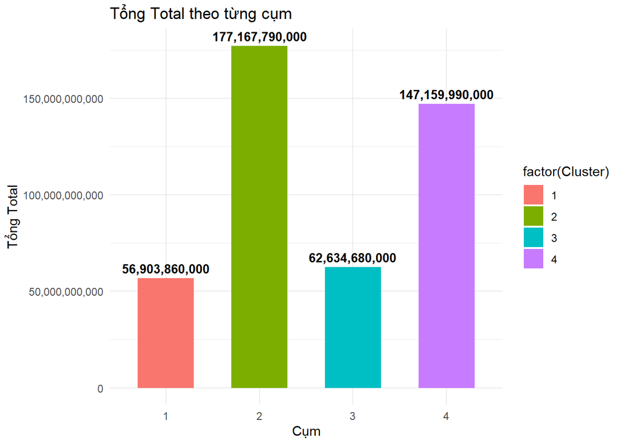

```r
# Tính tổng theo cụm
df_total <- df %>%
  group_by(Cluster) %>%
  summarise(total_total = sum(Total, na.rm = TRUE))

# Vẽ biểu đồ cột thể hiện tổng Total theo cụm
plot_total<- ggplot(df_total, aes(x = factor(Cluster), y = total_total, fill = factor(Cluster))) +
  geom_col(width = 0.6) +
  geom_text(aes(label = comma(total_total)),
            vjust = -0.5, color = "black", fontface = "bold", size = 3.5) +
  scale_y_continuous(labels = comma) +
  labs(title = "Tổng Total theo từng cụm",
       x = "Cụm", y = "Tổng Total") +
  theme_minimal()
plot_total
```

#### Biểu đồ hộp cho Price

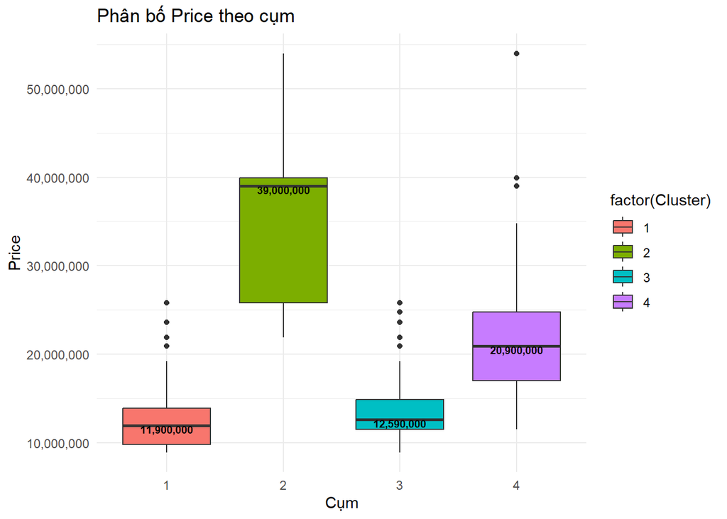

```r
plot_price <- ggplot(df, aes(x = factor(Cluster), y = Price, fill = factor(Cluster))) +
  geom_boxplot() +
  stat_summary(fun = median, geom = "text",
               aes(label = comma(..y..)),
               vjust = 0.9, color = "black", fontface = "bold",size=2.5) +
  # Để hiển thị giá trị y trực quan hơn
  scale_y_continuous(labels = comma) +
  labs(title = "Phân bố Price theo cụm",
       x = "Cụm", y = "Price") +
  theme_minimal()
plot_price
```

#### Biểu đồ hộp cho Quantity

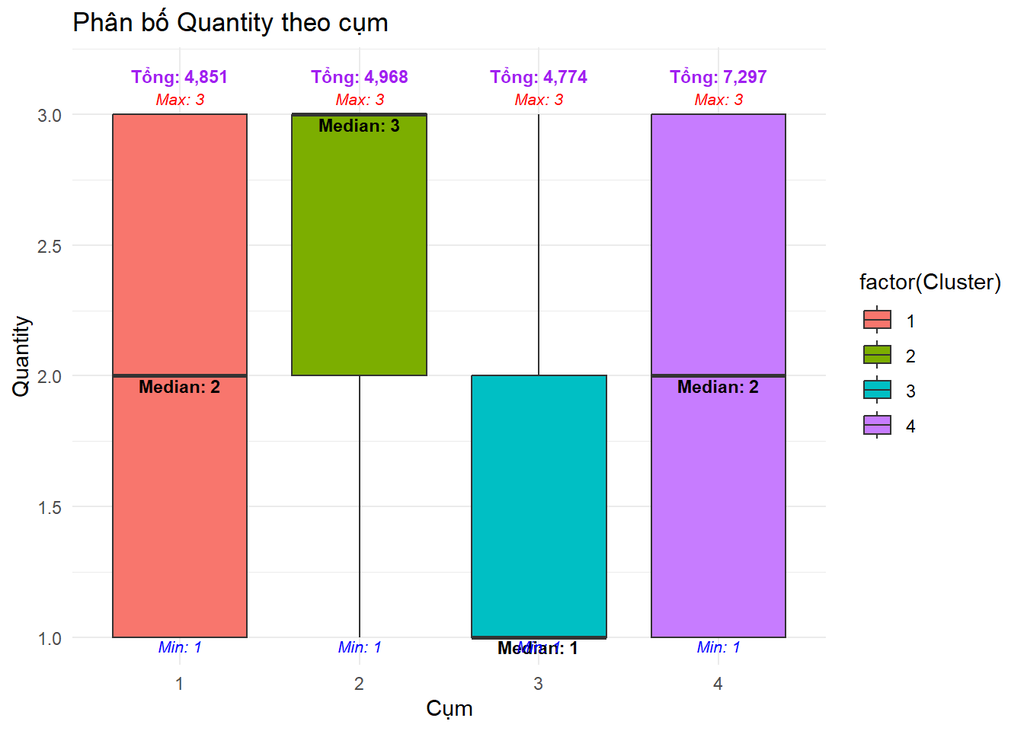

```r
# Tính tổng số lượng, Max,Min của mỗi đơn trong mỗi cụm.
df_summary <- df %>%
  group_by(Cluster) %>%
  summarise(
    total_quantity = sum(Quantity, na.rm = TRUE),
    min_quantity = min(Quantity, na.rm = TRUE),
    median_quantity = median(Quantity, na.rm = TRUE),
    max_quantity = max(Quantity, na.rm = TRUE)
  )
# Vẽ đồ thị thể hiện
plot_quantity <- ggplot(df, aes(x = factor(Cluster), y = Quantity, fill = factor(Cluster))) +
  geom_boxplot(outlier.shape = NA) +  # bỏ chấm outlier nếu rối
  geom_text(data = df_summary,
            aes(x = factor(Cluster), y = median_quantity,
                label = paste0("Median: ", comma(median_quantity))),
            color = "black", fontface = "bold", size = 3,
            inherit.aes = FALSE, vjust = 1.22) +
  # Thêm nhãn min count mỗi cụm
  geom_text(data = df_summary,
            aes(x = factor(Cluster), y = min_quantity,
                label = paste0("Min: ", comma(min_quantity))),
            color = "blue", fontface = "italic", size = 2.8,
            inherit.aes = FALSE, vjust = 1.2) +
  # Thêm nhãn max count mỗi cụm
  geom_text(data = df_summary,
            aes(x = factor(Cluster), y = max_quantity,
                label = paste0("Max: ", comma(max_quantity))),
            color = "red", fontface = "italic", size = 2.8,
            inherit.aes = FALSE, vjust = -0.8) +
  # Thêm nhãn tổng mỗi cụm
  geom_text(data = df_summary,
            aes(x = factor(Cluster), y = max_quantity * 1.05,
                label = paste0("Tổng: ", comma(total_quantity))),
            color = "purple", fontface = "bold", size = 3,
            inherit.aes = FALSE) +
  scale_y_continuous(labels = comma) +
  labs(title = "Phân bố Quantity theo cụm",
       x = "Cụm", y = "Quantity") +
  theme_minimal()
plot_quantity
```

#### Biểu đồ hộp cho Product_Name

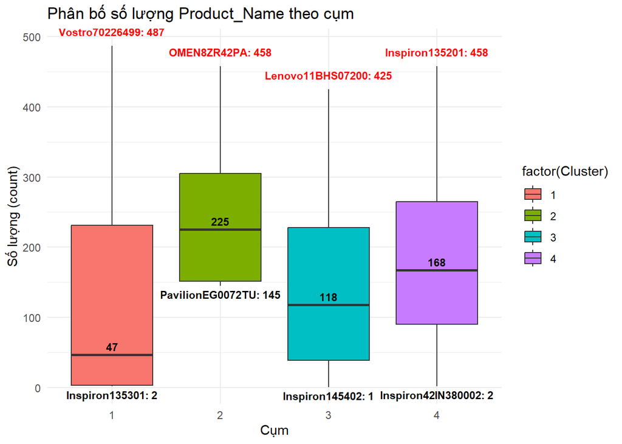

```r
library(dplyr)
library(ggplot2)
library(scales)

# Đếm số lượng từng Product_Name theo Cluster
df_counts <- df %>%
  group_by(Cluster, Product_Name) %>%
  summarise(count = n(), .groups = 'drop')

# Lấy max count mỗi cụm
df_max_count <- df_counts %>%
  group_by(Cluster) %>%
  filter(count == max(count)) %>%
  ungroup()
# Lấy min count mỗi cụm

df_min_count <- df_counts %>%
  group_by(Cluster) %>%
  slice_min(order_by = count, n = 1, with_ties = FALSE)  # chọn Product_Name có count nhỏ nhất trong mỗi cụm

# Vẽ boxplot số lượng sản phẩm theo Cluster
plot_pro_name <-ggplot(df_counts, aes(x = factor(Cluster), y = count, fill = factor(Cluster))) +
  geom_boxplot() +
  stat_summary(fun = median, geom = "text",
               aes(label = comma(..y..)),
               vjust = -0.5, color = "black", fontface = "bold", size=3) +
  # Thêm nhãn max count mỗi cụm
  geom_text(data = df_max_count,
            aes(x = factor(Cluster), y = count, label = paste0(Product_Name, ": ", count)),
            vjust = -1.2, color = "red", fontface = "bold", size=3,
            position = position_dodge(width = 0.75)) +
  # Thêm nhãn min count mỗi cụm
  geom_text(data = df_min_count,
            aes(x = factor(Cluster), y = count, label = paste0(Product_Name, ": ", count)),
            vjust = 1.5, color ="black", fontface = "bold", size=3,
            position = position_dodge(width = 0.75)) +
  scale_y_continuous(labels = comma) +
  labs(title = "Phân bố số lượng Product_Name theo cụm",
       x = "Cụm", y = "Số lượng (count)") +
  theme_minimal()
plot_pro_name
```

#### Biểu đồ hộp cho Month

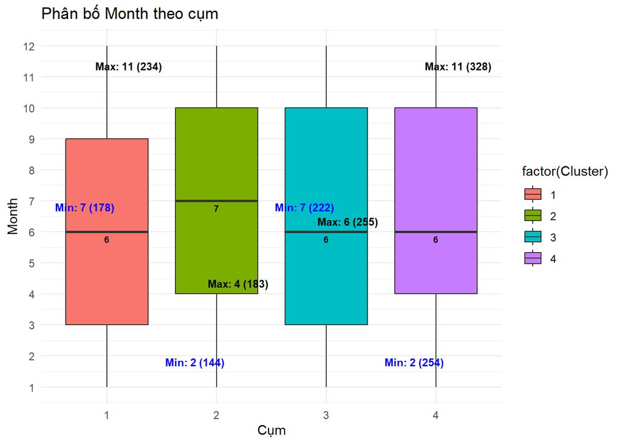

```r
# Đếm số đơn theo cụm và tháng
df_counts <- df %>%
  group_by(Cluster, Month) %>%
  summarise(count = n(), .groups = 'drop')

# Lấy tháng có nhiều đơn nhất mỗi cụm (có thể nhiều tháng trùng count → giữ hết)
df_max_count <- df_counts %>%
  group_by(Cluster) %>%
  filter(count == max(count)) %>%
  ungroup()

# Lấy tháng có ít đơn nhất mỗi cụm
df_min_count <- df_counts %>%
  group_by(Cluster) %>%
  filter(count == min(count)) %>%
  ungroup()

# Vẽ boxplot
plot_month <- ggplot(df, aes(x = factor(Cluster), y = Month, fill = factor(Cluster))) +
  geom_boxplot() +
  stat_summary(fun = median, geom = "text",
               aes(label = comma(..y..)),
               vjust = 1.5, color = "black", fontface = "bold", size = 2.5) +
  # Thêm nhãn max count mỗi cụm
  geom_text(data = df_max_count,
            aes(x = factor(Cluster), y = Month,
                label = paste0("Max: ", Month, " (", count, ")")),
            vjust = -0.8, color = "black", fontface = "bold", size = 3,
            position = position_nudge(x = 0.2)) +
  # Thêm nhãn min count mỗi cụm
  geom_text(data = df_min_count,
            aes(x = factor(Cluster), y = Month,
                label = paste0("Min: ", Month, " (", count, ")")),
            vjust = 1.2, color = "blue", fontface = "bold", size = 3,
            position = position_nudge(x = -0.2)) +

  scale_y_continuous(breaks = 1:12) +
  labs(title = "Phân bố Month theo cụm",
       x = "Cụm", y = "Month") +
  theme_minimal()

plot_month
```

#Nhân viên

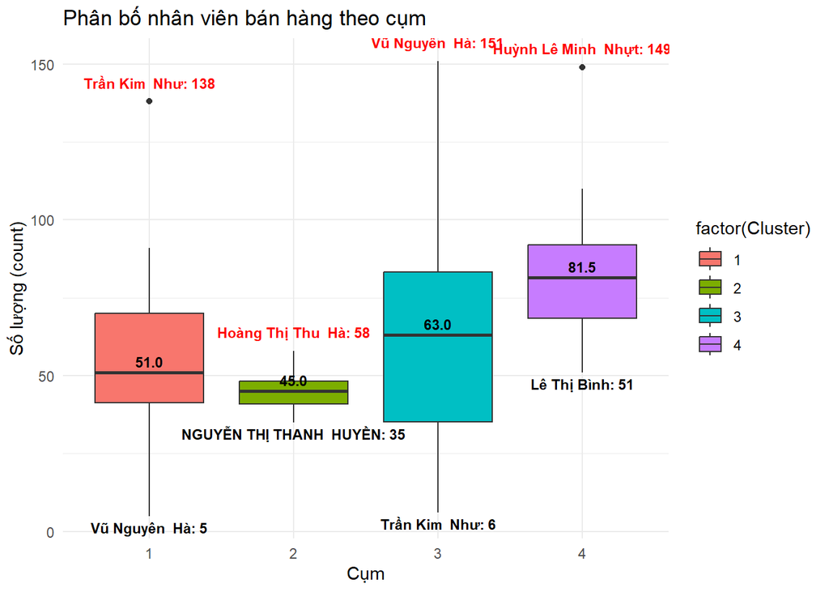

```r
# Đếm số lượng từng Nhân viên theo Cluster
df_counts <- df %>%
  group_by(Cluster, Saler_Name) %>%
  summarise(count = n(), .groups = 'drop')

# Lấy max count mỗi cụm
df_max_count <- df_counts %>%
  group_by(Cluster) %>%
  filter(count == max(count)) %>%
  ungroup()
# Lấy min count mỗi cụm

df_min_count <- df_counts %>%
  group_by(Cluster) %>%
  slice_min(order_by = count, n = 1, with_ties = FALSE)

# Vẽ boxplot số lượng sản phẩm theo Cluster
plot_saler_name <-ggplot(df_counts, aes(x = factor(Cluster), y = count, fill = factor(Cluster))) +
  geom_boxplot() +
  stat_summary(fun = median, geom = "text",
               aes(label = comma(..y..)),
               vjust = -0.5, color = "black", fontface = "bold", size=3) +
  # Thêm nhãn max count mỗi cụm
  geom_text(data = df_max_count,
            aes(x = factor(Cluster), y = count, label = paste0(Saler_Name, ": ", count)),
            vjust = -1.2, color = "red", fontface = "bold", size=3,
            position = position_dodge(width = 0.75)) +
  # Thêm nhãn min count mỗi cụm
  geom_text(data = df_min_count,
            aes(x = factor(Cluster), y = count, label = paste0(Saler_Name, ": ", count)),
            vjust = 1.5, color ="black", fontface = "bold", size=3,
            position = position_dodge(width = 0.75)) +
  scale_y_continuous(labels = comma) +
  labs(title = "Phân bố nhân viên bán hàng theo cụm",
       x = "Cụm", y = "Số lượng (count)") +
  theme_minimal()
plot_saler_name
```

## — Phân tích theo cụm —

### 1. Tháng được mua nhiều nhất mỗi cụm

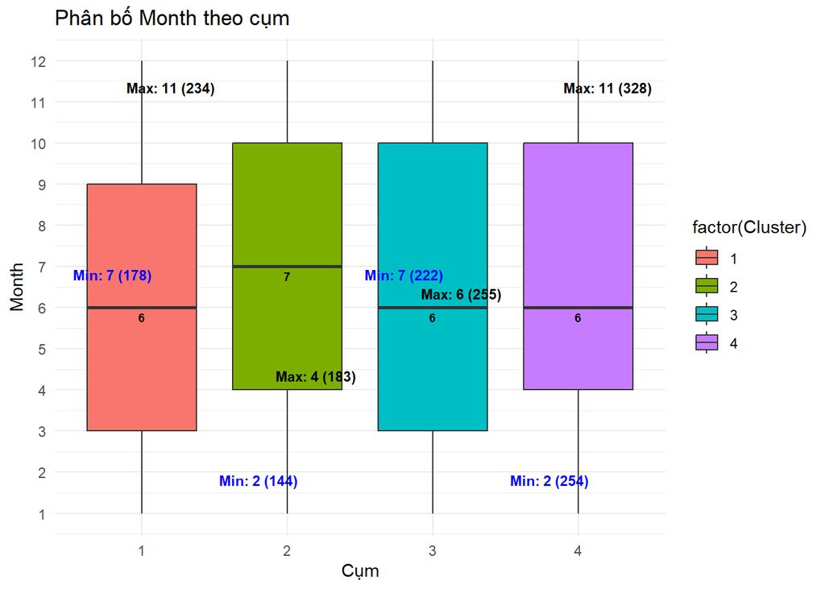

```r
plot_month
```

### 2. Sản phẩm bán chạy nhất mỗi cụm

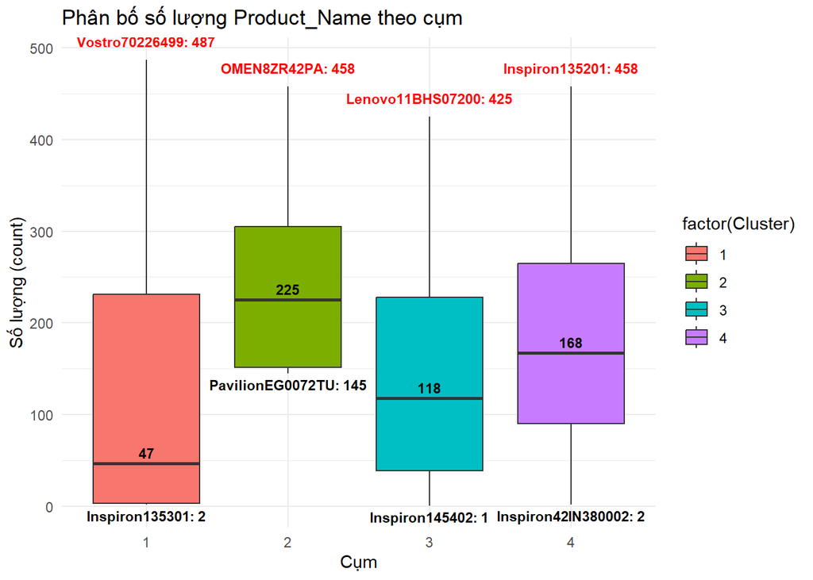

```r
plot_pro_name
```

### 3. Nhân viên bán chạy nhất mỗi cụm

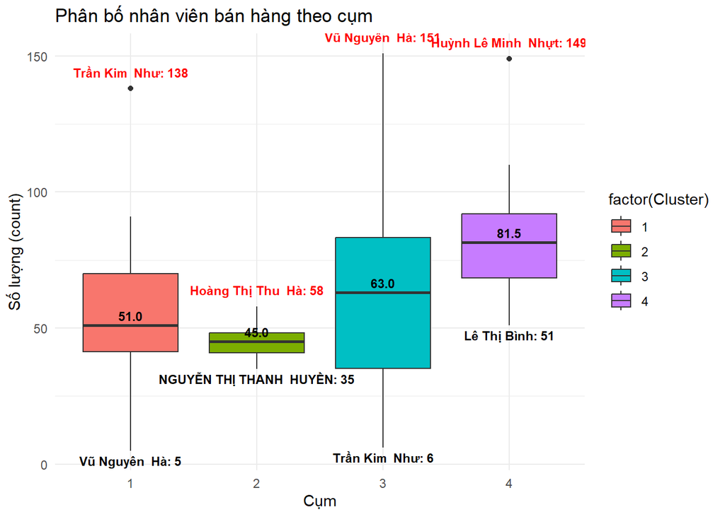

```r
plot_saler_name
```

### 4. Doanh thu theo cụm

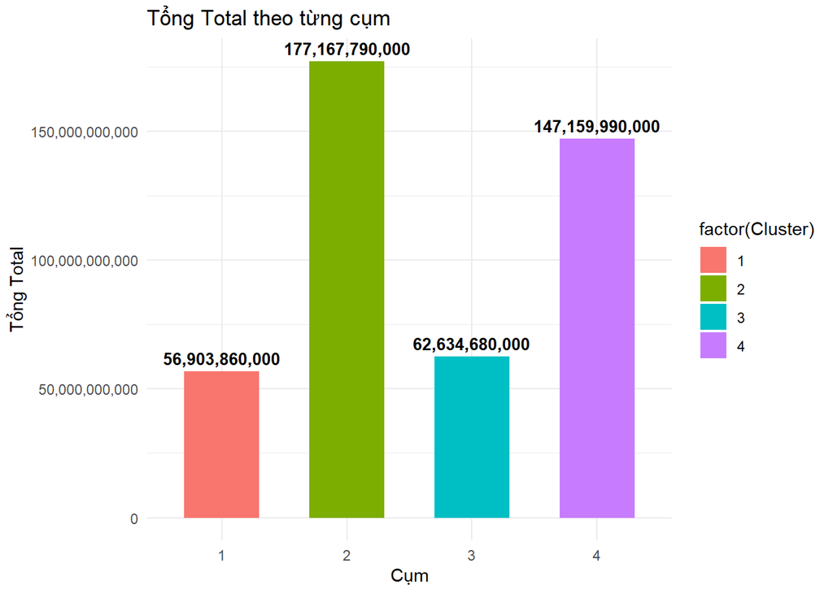

```r
plot_total
```

### 5. Tổng đơn hàng theo từng cụm, max/ min của 1 đơntheo từng cụm.

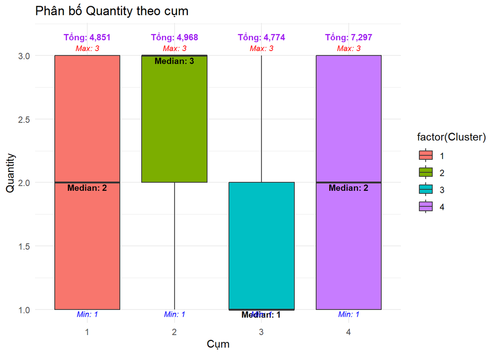

```r
plot_quantity
```

### 6. Sản phẩm ít được mua nhất

```r
library(dplyr)
df_min_products <- df %>%
  group_by(Branch_Name, Product_Name) %>%
  summarise(total_quantity = sum(Quantity, na.rm = TRUE), .groups = "drop") %>%
  group_by(Branch_Name) %>%
  slice_min(order_by = total_quantity, n = 1, with_ties = TRUE)  # Lấy sản phẩm ít nhất mỗi chi nhánh
df_min_products
```

```
## # A tibble: 5 × 3
## # Groups:   Branch_Name [5]
##   Branch_Name Product_Name       total_quantity
##   <chr>       <chr>                       <dbl>
## 1 Cần Thơ     ProBook1A1B0PA                109
## 2 Hà Nội      Inspiron42IN380002            188
## 3 Hải Phòng   Inspiron135201                 72
## 4 Hồ Chí Minh Inspiron42IN380002            221
## 5 Đà Nẵng     ProBook22X45AA                120
```

### 7. Sản phẩm được mua nhiều nhất từng chi nhánh

```r
df_max_products <- df %>%
  group_by(Branch_Name, Product_Name) %>%
  summarise(total_quantity = sum(Quantity, na.rm = TRUE), .groups = "drop") %>%
  group_by(Branch_Name) %>%
  slice_max(order_by = total_quantity, n = 1, with_ties = TRUE)  # Lấy sản phẩm nhiều nhất mỗi chi nhánh
df_max_products
```

```
## # A tibble: 5 × 3
## # Groups:   Branch_Name [5]
##   Branch_Name Product_Name      total_quantity
##   <chr>       <chr>                      <dbl>
## 1 Cần Thơ     Pavilion180S1AA              172
## 2 Hà Nội      Vostro70226499               258
## 3 Hải Phòng   Gaming81LK01J3VN             144
## 4 Hồ Chí Minh Inspiron135201               320
## 5 Đà Nẵng     Ideapad82H700DNVN            197
```

### 8. Nhân viên bán chạy trong năm

```r
top5_salers <- df %>%
  group_by(Saler_Name) %>%
  summarise(total_quantity = sum(Quantity, na.rm = TRUE), .groups = "drop") %>%
  arrange(desc(total_quantity)) %>%
  slice_head(n = 5)
top5_salers
```

```
## # A tibble: 5 × 2
##   Saler_Name          total_quantity
##   <chr>                        <dbl>
## 1 Kiều Ngọc Các                  551
## 2 Trịnh Thị Thu  Hằng            551
## 3 Vũ Nguyên  Hà                  549
## 4 Võ Thị Uyển  Nhi               538
## 5 Nguyễn Thành Tâm               532
```

### 9.Nhân viên bán kém nhất trong năm

```r
top3_salers <- df %>%
  group_by(Saler_Name) %>%
  summarise(total_quantity = sum(Quantity, na.rm = TRUE), .groups = "drop") %>%
  arrange(total_quantity) %>%
  slice_head(n = 3)
top3_salers
```

```
## # A tibble: 3 × 2
##   Saler_Name           total_quantity
##   <chr>                         <dbl>
## 1 Lê Thị Bình                     424
## 2 Hồ Thị Khánh  Huyền             440
## 3 Trần Lê Phương  Dung            450
```

### 10 . Nhân viên bán thấp hơn trung bình

- Ý tưởng: Tính số lượng sản phẩm bán được trên tổng số người bán để lấy 1 mức trung bình, những nhân viên có tổng lượng hàng bán dưới trung bình cần được thúc đẩy nâng cao năng suất, hiệu quả.

```r
saler_quantity <- df %>%
  group_by(Saler_Name) %>%
  summarise(total_quantity = sum(Quantity, na.rm = TRUE), .groups = "drop")
mean_quantity <- mean(saler_quantity$total_quantity)
below_average_salers <- saler_quantity %>%
  filter(total_quantity < mean_quantity)
below_average_salers
```

```
## # A tibble: 21 × 2
##    Saler_Name              total_quantity
##    <chr>                            <dbl>
##  1 Hồ Lê Lệ  Nguyên                   484
##  2 Hồ Thị Khánh  Huyền                440
##  3 Lê Thị Bình                        424
##  4 Lê Thị Phương  Thanh               488
##  5 Lê Thị Thùy  Linh                  462
##  6 Lương Thị  Thanh                   497
##  7 NGUYỄN THỊ THANH  HUYỀN            451
##  8 Nguyễn Gia  Hân                    496
##  9 Nguyễn Nhật  Hạ                    455
## 10 Nguyễn Thị  Hương                  483
## # ℹ 11 more rows
```

### 11. Tổng số lượng bán ra của từng hãng và tháng bán chạy nhất

```r
#Tổng số lượng của từng hãng
brand_quantity <- df %>%
  group_by(Product_Brand) %>%
  summarise(total_quantity = sum(Quantity, na.rm = TRUE), .groups = "drop") %>%
  arrange(desc(total_quantity))
#In ra kết quả
brand_quantity
```

```
## # A tibble: 3 × 2
##   Product_Brand total_quantity
##   <chr>                  <dbl>
## 1 Lenovo                  7332
## 2 HP                      7312
## 3 Dell                    7246
```

```r
#Tháng bán chạy nhất
monthly_brand_quantity <- df %>%
  group_by(Product_Brand, Month) %>% # Nhóm theo hãng và tháng
  summarise(monthly_quantity = sum(Quantity, na.rm = TRUE), .groups = "drop_last") %>%
  slice_max(order_by = monthly_quantity, n = 1) %>% # Chọn tháng có số lượng bán cao nhất cho mỗi hãng
  ungroup()

print(monthly_brand_quantity)
```

```
## # A tibble: 3 × 3
##   Product_Brand Month monthly_quantity
##   <chr>         <dbl>            <dbl>
## 1 Dell             11              673
## 2 HP                4              683
## 3 Lenovo            1              648
```

### 12. Doanh số theo tháng

```r
#Thống kê doanh thu theo tháng
month_revenue <- df %>%
  group_by(Month) %>%
  summarise(Tổng_doanh_thu  = sum(Total, na.rm = TRUE), .groups = "drop")
month_revenue
```

```
## # A tibble: 12 × 2
##    Month Tổng_doanh_thu
##    <dbl>          <dbl>
##  1     1    38117320000
##  2     2    33594580000
##  3     3    39872270000
##  4     4    39159930000
##  5     5    36085500000
##  6     6    36597880000
##  7     7    35519630000
##  8     8    36395350000
##  9     9    35469290000
## 10    10    37694120000
## 11    11    38666010000
## 12    12    36694440000
```

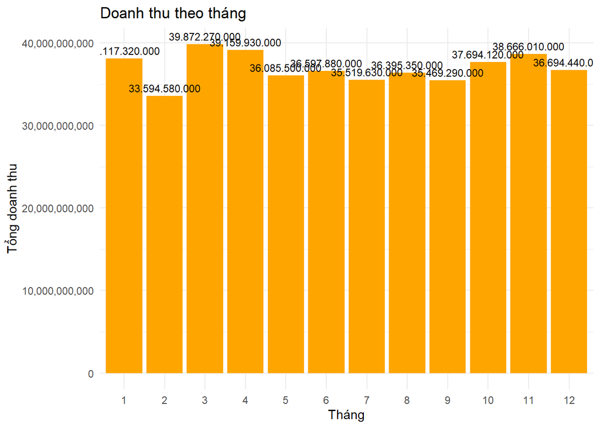

```r
#Vẽ đồ thị
ggplot(month_revenue, aes(x = factor(Month), y = Tổng_doanh_thu)) +
  geom_col(fill = "orange") +
  geom_text(aes(label = scales::comma(Tổng_doanh_thu, big.mark = ".", decimal.mark = ",")), # Hiển thị số có dấu chấm phân cách hàng nghìn
            vjust = -0.5, # Điều chỉnh vị trí của nhãn so với cột
            size = 3) + # Kích thước của chữ số
  labs(title = "Doanh thu theo tháng",
       x = "Tháng",
       y = "Tổng doanh thu") +
  scale_y_continuous(labels = scales::comma) + # Định dạng lại trục Y để không có "e"
  theme_minimal() +
  theme(axis.text.y = element_text(angle = 0, hjust = 1))
```

### 13. Best Seller mỗi tháng

```r
#  Tính sản phẩm bán chạy nhất mỗi tháng (dựa trên Tổng doanh thu)
best_seller_monthly <- df %>%
  group_by(Month, Product_Name) %>% # Nhóm theo tháng và sản phẩm
  summarise(Doanh_thu_san_pham = sum(Total, na.rm = TRUE), .groups = "drop_last") %>% # Tính tổng doanh thu cho từng sản phẩm trong tháng
  slice_max(order_by = Doanh_thu_san_pham, n = 1) %>% # Chọn sản phẩm có doanh thu cao nhất cho mỗi tháng
  ungroup() # Bỏ nhóm để có một dataframe phẳng

# Hiển thị kết quả sản phẩm bán chạy nhất mỗi tháng
print(best_seller_monthly,12)
```

```
## # A tibble:
## #   12 × 3
##    Month
##    <dbl>
##  1     1
##  2     2
##  3     3
##  4     4
##  5     5
##  6     6
##  7     7
##  8     8
##  9     9
## 10    10
## 11    11
## 12    12
## # ℹ 2 more
## #   variables:
## #   Product_Name <chr>,
## #   Doanh_thu_san_pham <dbl>
```

### 14. Đánh giá doanh thu theo tháng, quý, xem xét mức độ tăng trưởng

```r
library(dplyr)
library(lubridate) # Để xử lý ngày tháng
library(tidyr)

df_14 <- df %>%
  mutate(
    Year = year(Date),
    Month = month(Date),
    Quarter = quarter(Date)
  )

# 1. Tính toán doanh thu theo tháng
month_revenue_full_date <- df_14 %>%
  group_by(Year, Month) %>%
  summarise(Tong_doanh_thu = sum(Total, na.rm = TRUE), .groups = "drop") %>%
  arrange(Year, Month)

# 2. Tính toán tăng trưởng doanh thu so với tháng trước
month_revenue_growth <- month_revenue_full_date %>%
  mutate(
    Doanh_thu_thang_truoc = lag(Tong_doanh_thu, n = 1),
    Tang_truong_thang = (Tong_doanh_thu - Doanh_thu_thang_truoc) / Doanh_thu_thang_truoc * 100
  )

print(month_revenue_growth)
```

```
## # A tibble: 12 × 5
##     Year Month Tong_doanh_thu Doanh_thu_thang_truoc Tang_truong_thang
##    <dbl> <dbl>          <dbl>                 <dbl>             <dbl>
##  1  2020     1    38117320000                    NA             NA
##  2  2020     2    33594580000           38117320000            -11.9
##  3  2020     3    39872270000           33594580000             18.7
##  4  2020     4    39159930000           39872270000             -1.79
##  5  2020     5    36085500000           39159930000             -7.85
##  6  2020     6    36597880000           36085500000              1.42
##  7  2020     7    35519630000           36597880000             -2.95
##  8  2020     8    36395350000           35519630000              2.47
##  9  2020     9    35469290000           36395350000             -2.54
## 10  2020    10    37694120000           35469290000              6.27
## 11  2020    11    38666010000           37694120000              2.58
## 12  2020    12    36694440000           38666010000             -5.10
```

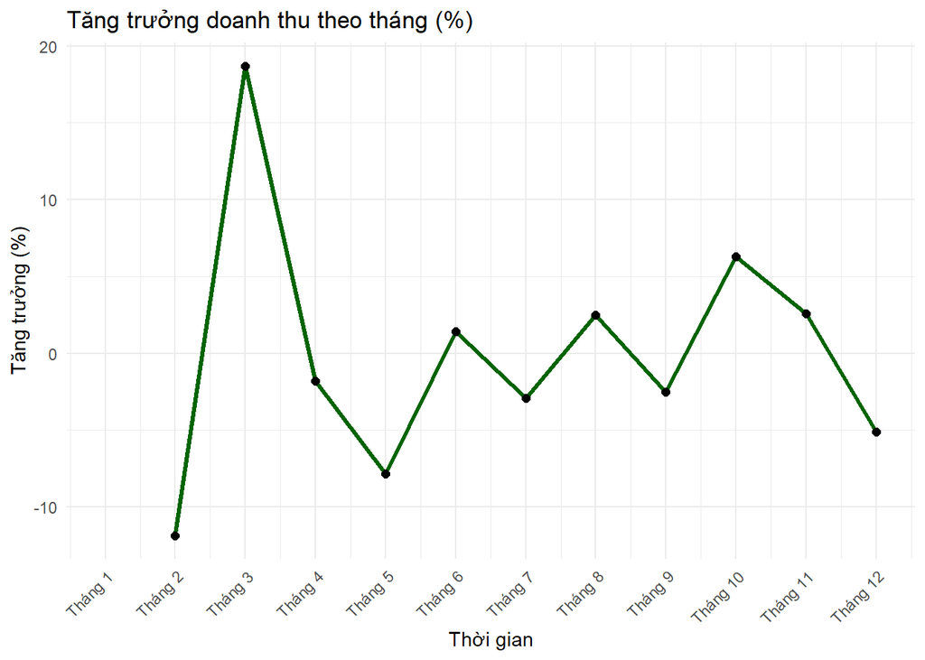

```r
## Biểu đồ đường
library(ggplot2)
ggplot(month_revenue_growth, aes(x = Month, y = Tang_truong_thang)) +
  geom_line(color = "darkgreen", size = 1.2) +
  geom_point(color = "black", size = 2) +
  labs(
    title = "Tăng trưởng doanh thu theo tháng (%)",
    x = "Thời gian",
    y = "Tăng trưởng (%)"
  ) +
  scale_x_continuous(breaks = 1:12, labels = paste0("Tháng ", 1:12)) +
  theme_minimal() +
  theme(axis.text.x = element_text(angle = 45, hjust = 1))
```

```r
# 3. Tính toán doanh thu theo quý và tăng trưởng so với quý trước
quarter_revenue_full_date <- df_14 %>%
  group_by(Year, Quarter) %>%
  summarise(Tong_doanh_thu_quy = sum(Total, na.rm = TRUE), .groups = "drop") %>%
  arrange(Year, Quarter)

quarter_revenue_growth <- quarter_revenue_full_date %>%
  mutate(
    Doanh_thu_quy_truoc = lag(Tong_doanh_thu_quy, n = 1),
    Tang_truong_quy = (Tong_doanh_thu_quy - Doanh_thu_quy_truoc) / Doanh_thu_quy_truoc * 100
  )

print(quarter_revenue_growth)
```

```
## # A tibble: 4 × 5
##    Year Quarter Tong_doanh_thu_quy Doanh_thu_quy_truoc Tang_truong_quy
##   <dbl>   <int>              <dbl>               <dbl>           <dbl>
## 1  2020       1       111584170000                  NA          NA
## 2  2020       2       111843310000        111584170000           0.232
## 3  2020       3       107384270000        111843310000          -3.99
## 4  2020       4       113054570000        107384270000           5.28
```

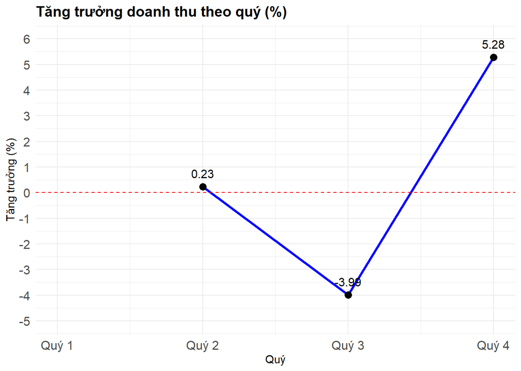

```r
## Vẽ biểu đồ
ggplot(quarter_revenue_growth, aes(x = Quarter, y = Tang_truong_quy, group = 1)) +
  geom_line(color = "blue", size = 1.2) +
  geom_point(color = "black", size = 3) +
  geom_text(aes(label = round(Tang_truong_quy, 2)), vjust = -1, size = 4, color = "black") +
  geom_hline(yintercept = 0, linetype = "dashed", color = "red") +
  scale_x_continuous(breaks = 1:4, labels = paste0("Quý ", 1:4)) +
  scale_y_continuous(limits = c(-5, 6), breaks = seq(-5, 6, by = 1)) +
  labs(
    title = "Tăng trưởng doanh thu theo quý (%)",
    x = "Quý",
    y = "Tăng trưởng (%)"
  ) +
  theme_minimal() +
  theme(
    axis.text.x = element_text(size = 12),
    axis.text.y = element_text(size = 12),
    plot.title = element_text(size = 14, face = "bold")
  )
```

## Dự báo

### 1. Dự báo doanh thu năm tới

```r
library(dplyr)
library(lubridate)
library(forecast)
```

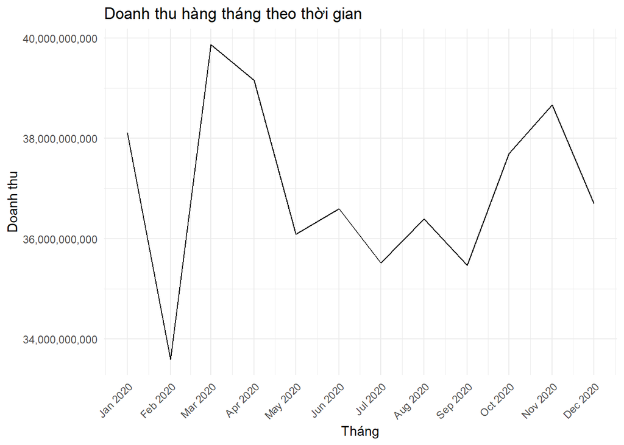

```r
library(ggplot2)


# 1. Tổng hợp doanh thu theo tháng
df_with_year_col <- df %>%
  mutate(Year = year(Date))

monthly_sales <- df %>%
  mutate(Date = floor_date(as.Date(Date), "month")) %>% # Đảm bảo cột Date ở định dạng ngày tháng và làm tròn về đầu tháng
  group_by(Date) %>%
  summarise(Total_Revenue = sum(Total, na.rm = TRUE), .groups = "drop") %>%
  arrange(Date)

# Chuyển đổi thành đối tượng chuỗi thời gian (ts object)
start_year <- year(min(monthly_sales$Date))
start_month <- month(min(monthly_sales$Date))

sales_ts <- ts(monthly_sales$Total_Revenue,
               start = c(start_year, start_month),
               frequency = 12) # Tần suất 12 cho dữ liệu hàng tháng

# 2. Phân tích chuỗi thời gian
# Trực quan doanh thu theo tháng với nhãn thời gian chi tiết
ggplot(monthly_sales, aes(x = Date, y = Total_Revenue)) +
  geom_line() +
  scale_x_date(date_labels = "%b %Y", date_breaks = "1 month") +
  scale_y_continuous(labels = label_comma()) +
  labs(title = "Doanh thu hàng tháng theo thời gian",
       x = "Tháng",
       y = "Doanh thu") +
  theme_minimal() +
  theme(axis.text.x = element_text(angle = 45, hjust = 1))
```

```r
# 3. Lựa chọn và huấn luyện mô hình (ví dụ: auto.arima)
# Huấn luyện mô hình ARIMA
fit_arima <- auto.arima(sales_ts)
summary(fit_arima)
```

```
## Series: sales_ts
## ARIMA(0,0,0) with non-zero mean
##
## Coefficients:
##              mean
##       36988860000
## s.e.    491521509
##
## sigma^2 = 3.183e+18:  log likelihood = -272.13
## AIC=548.26   AICc=549.59   BIC=549.23
##
## Training set error measures:
##                         ME       RMSE        MAE        MPE     MAPE MASE
## Training set -7.629395e-06 1708019622 1427558333 -0.2153547 3.872814  NaN
##                    ACF1
## Training set -0.1999464
```

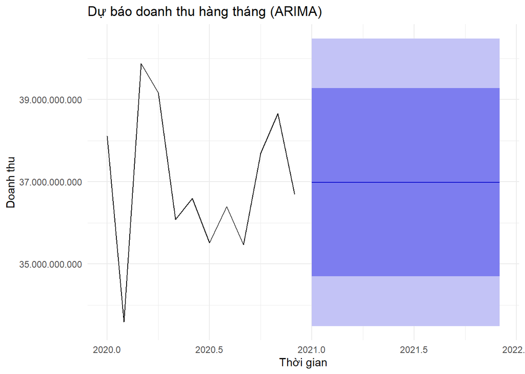

```r
# Tạo dự báo
forecast_arima <- forecast(fit_arima, h = 12)

# Vẽ biểu đồ dự báo ARIMA
autoplot(forecast_arima) +
  labs(title = "Dự báo doanh thu hàng tháng (ARIMA)",
       y = "Doanh thu",
       x = "Thời gian") +
  scale_y_continuous(labels = label_number(big.mark = ".", decimal.mark = ",")) +
  theme_minimal()
```

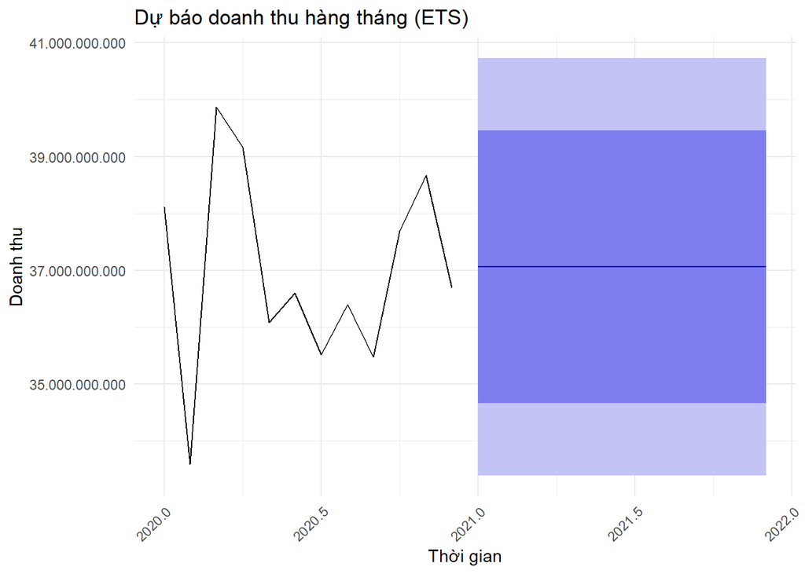

```r
# Tương tự với ETS
fit_ets <- ets(sales_ts)
forecast_ets <- forecast(fit_ets, h = 12)

# Biểu đồ ETS
autoplot(forecast_ets) +
  labs(title = "Dự báo doanh thu hàng tháng (ETS)",
       y = "Doanh thu",
       x = "Thời gian") +
  scale_y_continuous(labels = label_number(big.mark = ".", decimal.mark = ",")) +
  theme_minimal() +
  theme(axis.text.x = element_text(angle = 45, hjust = 1))
```

```r
# Tạo bảng so sánh giữa ARIMA và ETS
library(lubridate)
library(scales)

future_months <- seq(from = as.Date(max(monthly_sales$Date)) %m+% months(1),
                     by = "month",
                     length.out = 12)

forecast_compare <- data.frame(
  Tháng = format(future_months, "%Y-%m"),
  Du_bao_ARIMA = formatC(as.numeric(forecast_arima$mean), format = "f", big.mark = ".",decimal.mark = ",", digits = 0),
  Du_bao_ETS = formatC(as.numeric(forecast_ets$mean), format = "f", big.mark = ".",decimal.mark = ",", digits = 0)
)

# Hiển thị bảng
library(knitr)
kable(forecast_compare, caption = "So sánh dự báo doanh thu giữa mô hình ARIMA và ETS")
```

So sánh dự báo doanh thu giữa mô hình ARIMA và ETS

| Tháng | Du_bao_ARIMA | Du_bao_ETS |
| --- | --- | --- |
| 2021-01 | 36.988.860.000 | 37.063.087.470 |
| 2021-02 | 36.988.860.000 | 37.063.087.470 |
| 2021-03 | 36.988.860.000 | 37.063.087.470 |
| 2021-04 | 36.988.860.000 | 37.063.087.470 |
| 2021-05 | 36.988.860.000 | 37.063.087.470 |
| 2021-06 | 36.988.860.000 | 37.063.087.470 |
| 2021-07 | 36.988.860.000 | 37.063.087.470 |
| 2021-08 | 36.988.860.000 | 37.063.087.470 |
| 2021-09 | 36.988.860.000 | 37.063.087.470 |
| 2021-10 | 36.988.860.000 | 37.063.087.470 |
| 2021-11 | 36.988.860.000 | 37.063.087.470 |
| 2021-12 | 36.988.860.000 | 37.063.087.470 |

#2.Dự báo nhu cầu hàng hóa

```r
#1. Tiền xử lí dữ liệu
library(dplyr)

#Tổng hợp doanh số theo chi nhánh và sản phẩm
sales_by_branch <- df %>%
  group_by(Branch_Name,Product_Brand) %>%
  summarise(Total_Sales = sum(Total),Avg_Quantity = mean(Quantity))
#Kiểm tra dữ liệu
head(sales_by_branch)
```

```
## # A tibble: 6 × 4
## # Groups:   Branch_Name [2]
##   Branch_Name Product_Brand Total_Sales Avg_Quantity
##   <chr>       <chr>               <dbl>        <dbl>
## 1 Cần Thơ     Dell          21353460000         1.98
## 2 Cần Thơ     HP            27457040000         1.99
## 3 Cần Thơ     Lenovo        20669180000         2.04
## 4 Hà Nội      Dell          34530550000         2.01
## 5 Hà Nội      HP            45788230000         1.99
## 6 Hà Nội      Lenovo        33715380000         2.00
```

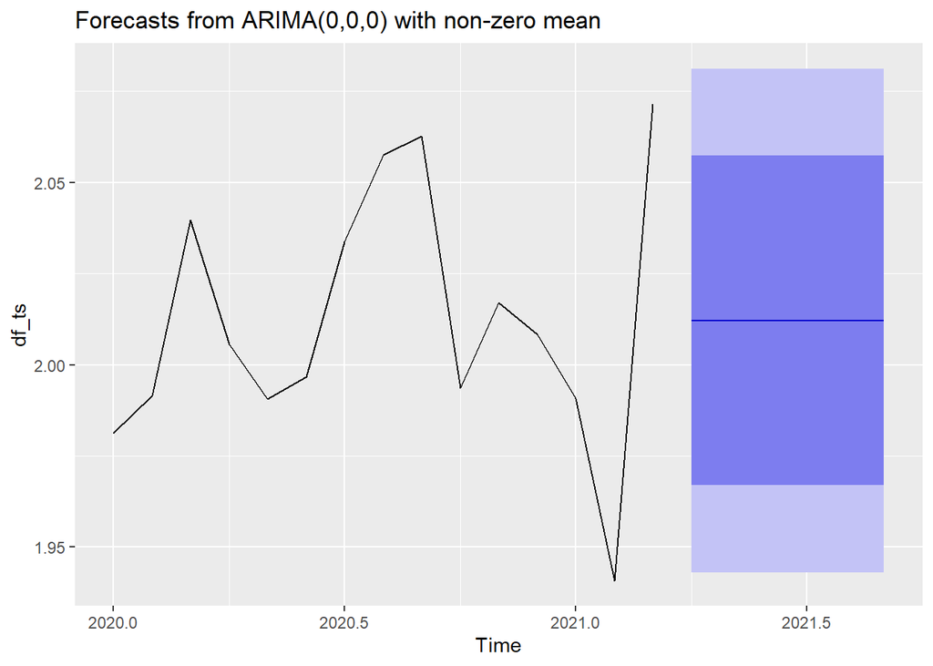

```r
#2. Dự báo nhu cầu khách hàng theo chi nhánh
library(forecast)

#Chuyển đổi dữ liệu thành chuỗi thời gian
start_year <- year(min(monthly_sales$Date))
start_month <- month(min(monthly_sales$Date))

df_ts <- ts(sales_by_branch$Avg_Quantity,
            start = c(start_year, start_month),
            frequency = 12)

#Xây dựng mô hình ARIMA
model_arima <- auto.arima(df_ts)

#Dự báo nhu cầu hàng hóa trong 6 tháng tới
forecast_values <- forecast(model_arima, h=6)

#Hiển thị kết quả
autoplot(forecast_values)
```

#3.Tối ưu mức tồn kho bằng machine learning Random Forest

```r
library(randomForest)
#Chuẩn bị dữ liệu cho mô hình
inventory_data <- df %>%
  select(Branch_Name,Product_Brand, Quantity, Total)

#Chia tập dữ liệu thành tập huấn luyện và kiểm tra
set.seed(123)
train_index <- sample(1:nrow(inventory_data),0.7*nrow(inventory_data))
train_data <- inventory_data[train_index,]
test_data <- inventory_data[-train_index,]

#Xây dựng mô hình Random Forest
model_rf <- randomForest(Quantity ~ Branch_Name+Product_Brand+Total, data=train_data,ntree=50)
```

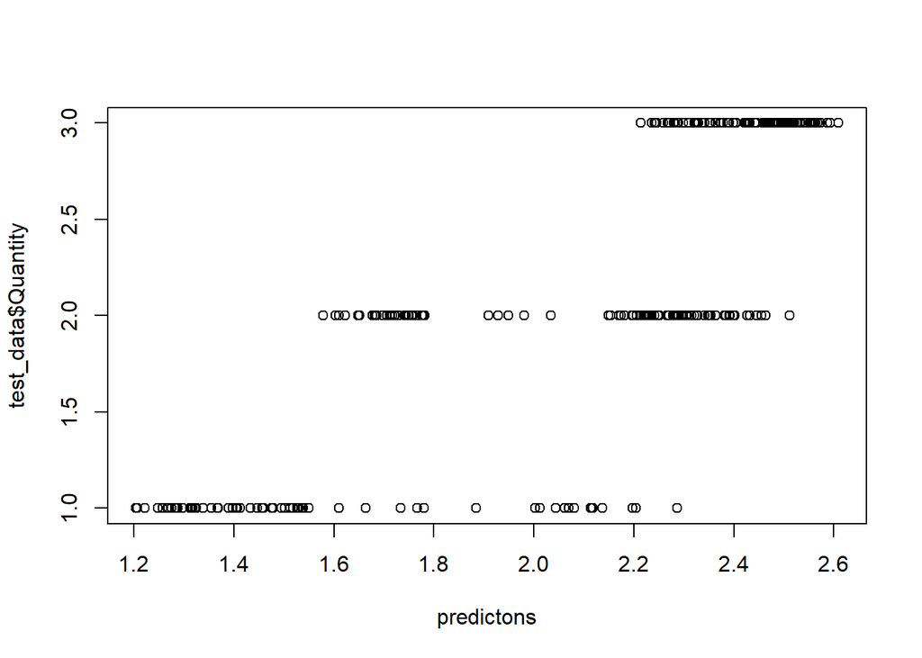

```r
#Dự đoán mức tồn kho tối ưu
predictons <- predict(model_rf,test_data)

#Kiểm tra kết quả
plot(predictons, test_data$Quantity)
```

```r
cor(predictons, test_data$Quantity)
```

```
## [1] 0.8506017
```

```r
library(dplyr)

# Tạo danh sách lưu dự báo theo từng chi nhánh
forecast_list <- lapply(unique(sales_by_branch$Branch_Name), function(branch) {
  # Lọc dữ liệu theo chi nhánh
  branch_data <- sales_by_branch %>% filter(Branch_Name == branch)

  # Chuyển đổi dữ liệu thành chuỗi thời gian
  df_ts <- ts(branch_data$Avg_Quantity, frequency = 12)

  # Xây dựng mô hình ARIMA
  model_arima <- auto.arima(df_ts)

  # Dự báo nhu cầu trong 6 tháng tới
  forecast_values <- forecast(model_arima, h=6)

  # Lưu kết quả dự báo
  data.frame(Branch_Name = branch, Forecasted_Quantity = forecast_values$mean)
})

# Gộp danh sách lại thành bảng
forecast_table <- bind_rows(forecast_list)

# Hiển thị kết quả
print(forecast_table)
```

```
##    Branch_Name Forecasted_Quantity
## 1      Cần Thơ            2.004145
## 2      Cần Thơ            2.004145
## 3      Cần Thơ            2.004145
## 4      Cần Thơ            2.004145
## 5      Cần Thơ            2.004145
## 6      Cần Thơ            2.004145
## 7       Hà Nội            1.997626
## 8       Hà Nội            1.997626
## 9       Hà Nội            1.997626
## 10      Hà Nội            1.997626
## 11      Hà Nội            1.997626
## 12      Hà Nội            1.997626
## 13   Hải Phòng            2.051391
## 14   Hải Phòng            2.051391
```

[output cut: 16 more lines]

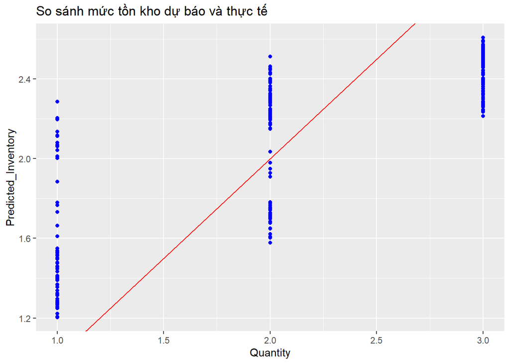

```r
#4.Kiểm tra hiệu suất dự báo
library(ggplot2)

#So sánh dự báo với dữ liệu thực tế
df$Predicted_Inventory <- predict(model_rf, df)

ggplot(df, aes(x = Quantity, y = Predicted_Inventory)) +
  geom_point(color = "blue")+
  geom_abline(intercept = 0, slope = 1, color = "red")+
  ggtitle("So sánh mức tồn kho dự báo và thực tế")
```